# White Wine Dataset - Explore and Summarize Data by James Tooles

```
##
##  Pearson's product-moment correlation
##
## data:  wine$quality and wine$total.sulfur.dioxide
## t = -12.418, df = 4896, p-value < 2.2e-16
## alternative hypothesis: true correlation is not equal to 0
## 95 percent confidence interval:
##  -0.2017563 -0.1474524
## sample estimates:
##        cor
## -0.1747372
```

As the quality of the wines increase, the limits for total sulfur dioxide values seem to converge from 80 to 140, with the low quality wines having a much larger variation of total sulfur dioxide values, about 20 to 280. This analysis only tells us part of the story given the correlation value of -0.175 for quality vs total sulfur dioxide.

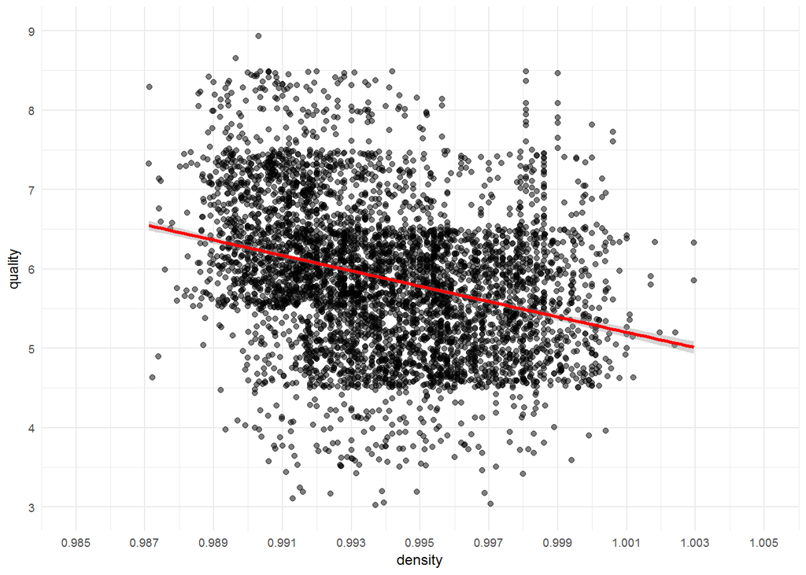

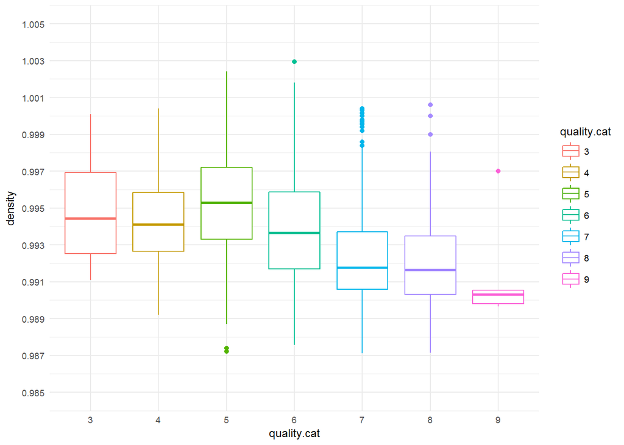

```
##
##  Pearson's product-moment correlation
##
## data:  wine$quality and wine$density
## t = -22.581, df = 4896, p-value < 2.2e-16
## alternative hypothesis: true correlation is not equal to 0
## 95 percent confidence interval:
##  -0.3322718 -0.2815385
## sample estimates:
##        cor
## -0.3071233
```

The high quality wines have a low density value, only the sub-par wines have high density values. The density and quality of wine has a decent correlation value of -0.307.

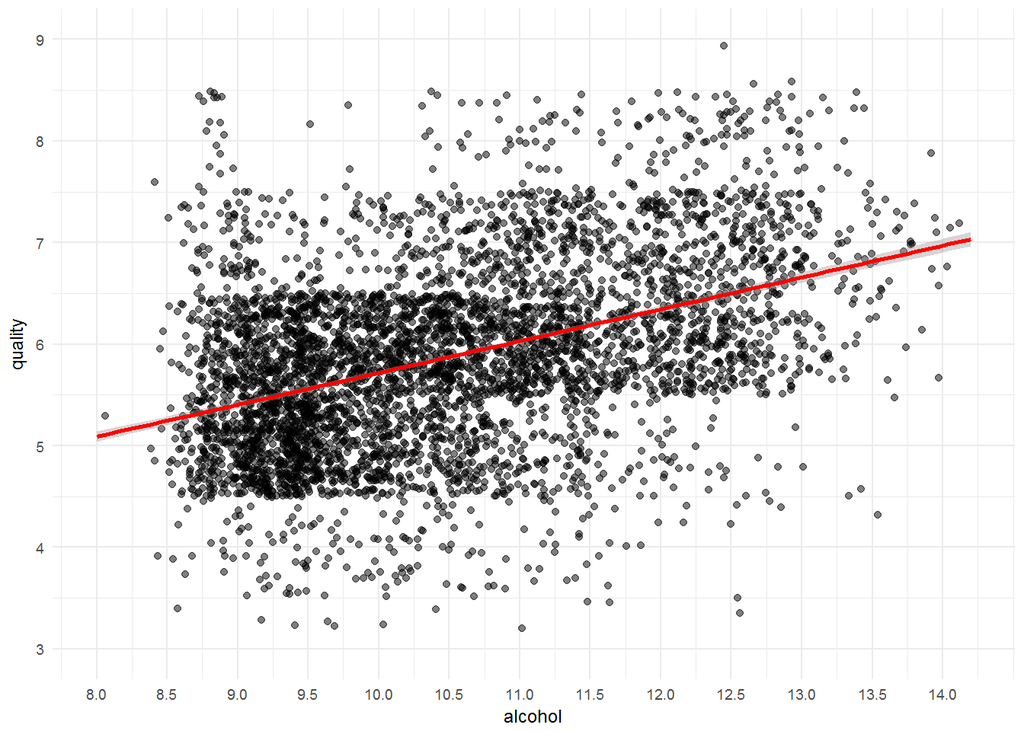

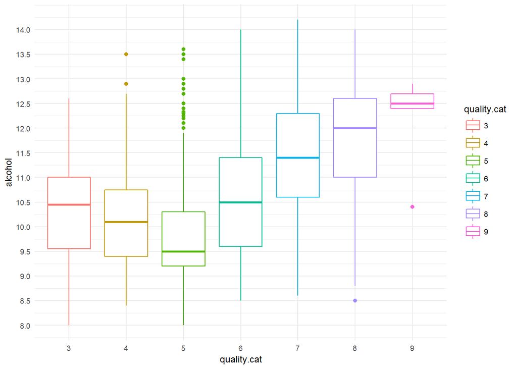

```
##
##  Pearson's product-moment correlation
##
## data:  wine$quality and wine$alcohol
## t = 33.858, df = 4896, p-value < 2.2e-16
## alternative hypothesis: true correlation is not equal to 0
## 95 percent confidence interval:
##  0.4126015 0.4579941
## sample estimates:
##       cor
## 0.4355747
```

The high quality wines have a higher alcohol value, only the sub-par wines have lower alcohol values. Only a small portion of wines have high quality and low alcohol content. The quality and alcohol features have the highest correlation yet, at a value of 0.436.

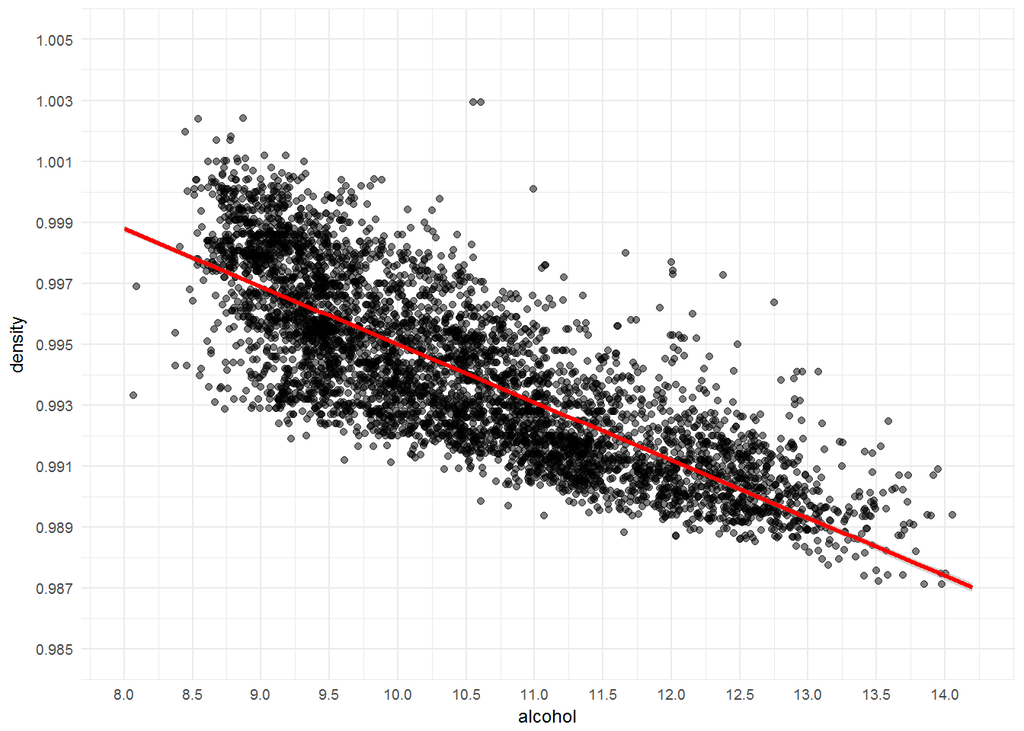

```
##
##  Pearson's product-moment correlation
##
## data:  wine$density and wine$alcohol
## t = -87.255, df = 4896, p-value < 2.2e-16
## alternative hypothesis: true correlation is not equal to 0
## 95 percent confidence interval:
##  -0.7908646 -0.7689315
## sample estimates:
##        cor
## -0.7801376
```

As the alcohol values increase, the density decreases. This could be due to alcohol having a lower density than the rest of the wine content, therefore bringing down the overall density of the wine. Alcohol and density have a strong negative correlation value of -0.780.

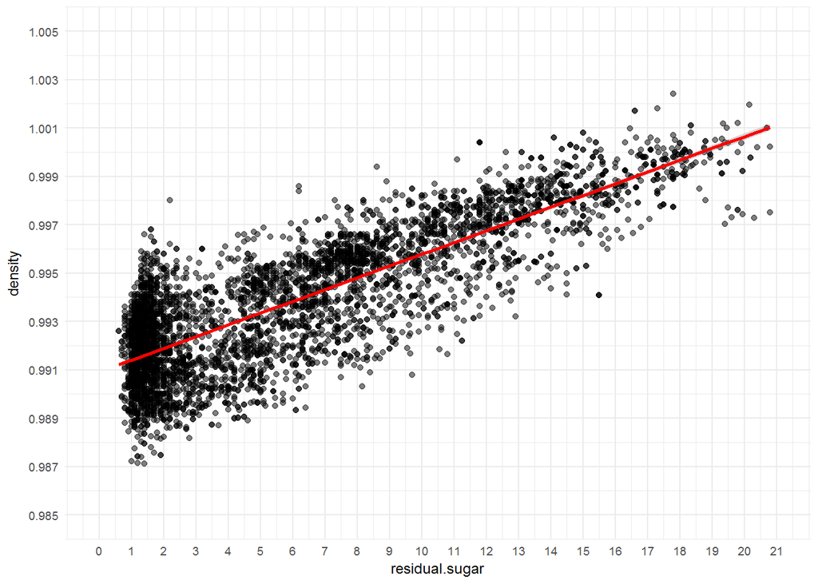

```
##
##  Pearson's product-moment correlation
##
## data:  wine$density and wine$residual.sugar
## t = 107.87, df = 4896, p-value < 2.2e-16
## alternative hypothesis: true correlation is not equal to 0
## 95 percent confidence interval:
##  0.8304732 0.8470698
## sample estimates:
##       cor
## 0.8389665
```

The residual sugar and density have a strong positive correlation of 0.839. As the residual sugar increases, the density increases. This could be due to the fact that residual sugar has a higher density compared to the remaining wine content. This could also be related to the fact that during fermentation, sugar is turned into alcohol. So the less sugar turned into lower density alcohol, the higher the density of the wine.

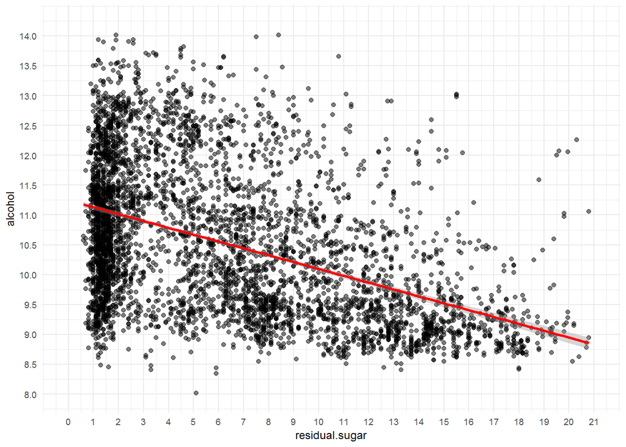

```
##
##  Pearson's product-moment correlation
##
## data:  wine$alcohol and wine$residual.sugar
## t = -35.321, df = 4896, p-value < 2.2e-16
## alternative hypothesis: true correlation is not equal to 0
## 95 percent confidence interval:
##  -0.4726723 -0.4280267
## sample estimates:
##        cor
## -0.4506312
```

The alcohol content and residual.sugar have a moderate negative correlation of -0.451. As the residual sugar increases, the alcohol content decreases. This is most likely due to the fermination process of making acohol, which consumes sugar to produce alcohol.

# Bivariate Analysis

### Talk about some of the relationships you observed in this part of the investigation. How did the features of interest vary with other features in the dataset?

The relationship between volatile acidity and quality of wines has a parabolic shape, in the sense that the low and high quality wines have a higher level of volatile acidity, while the average wines have a lower volatile acidity.

For the chlorides levels, the chlorides values decrease as the quality of wine increases.

The total sulfur dioxide has one of the most interesting relationships to quality, as it converges to a total sulfur dioxide range of 80 to 140 as the quality of wine increases. The lower quality wines have a much larger variation of total sulfur dioxide values.

The wine density decreases as the wine quality increase, with a significant drop as the wine quality equals 9.

As the median alcohol level increases, the wine quality increases. The alcohol feature has the highest correlation with wine quality out of all of the given features.

### Did you observe any interesting relationships between the other features (not the main features) of interest)?

The density, alcohol, and residual sugar features seem to be highly correlated with each other. The alcohol is created by consuming sugar during the fermentation process, and the more alcohol within the wine the lower the density of the wine given the density of the alcohol relative to residual sugar and the remaining wine content.

# Multivariate Plots Section

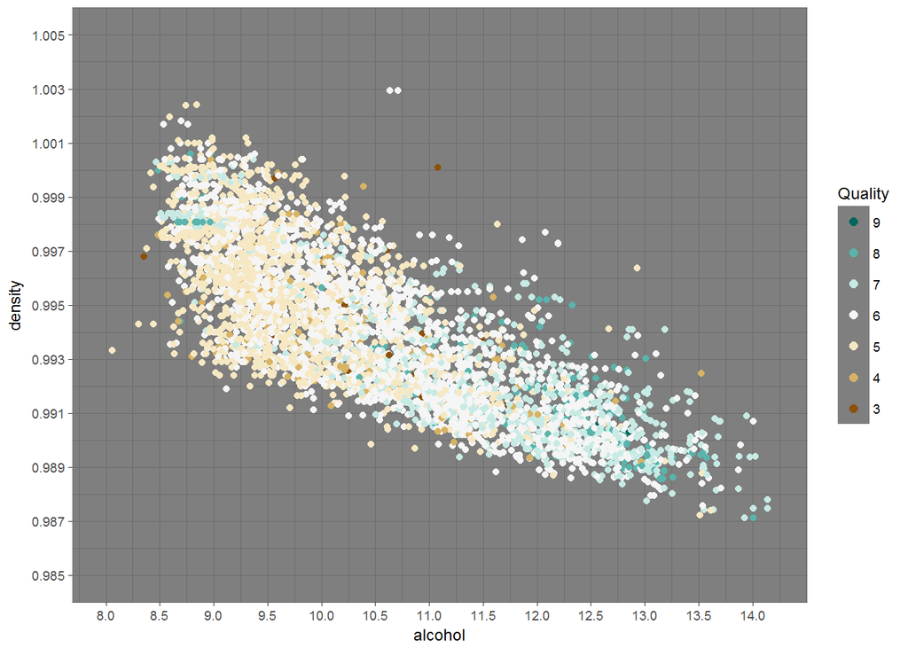

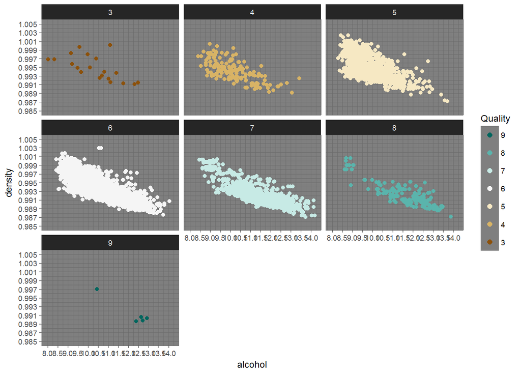

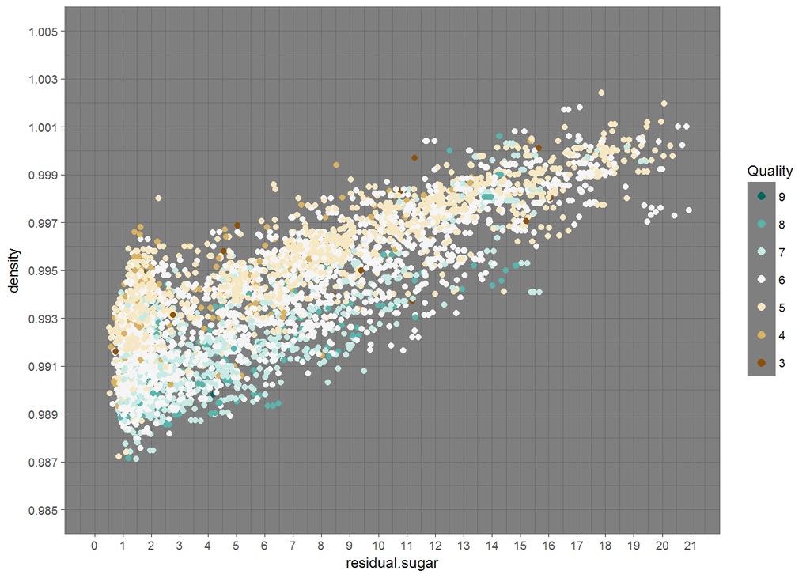

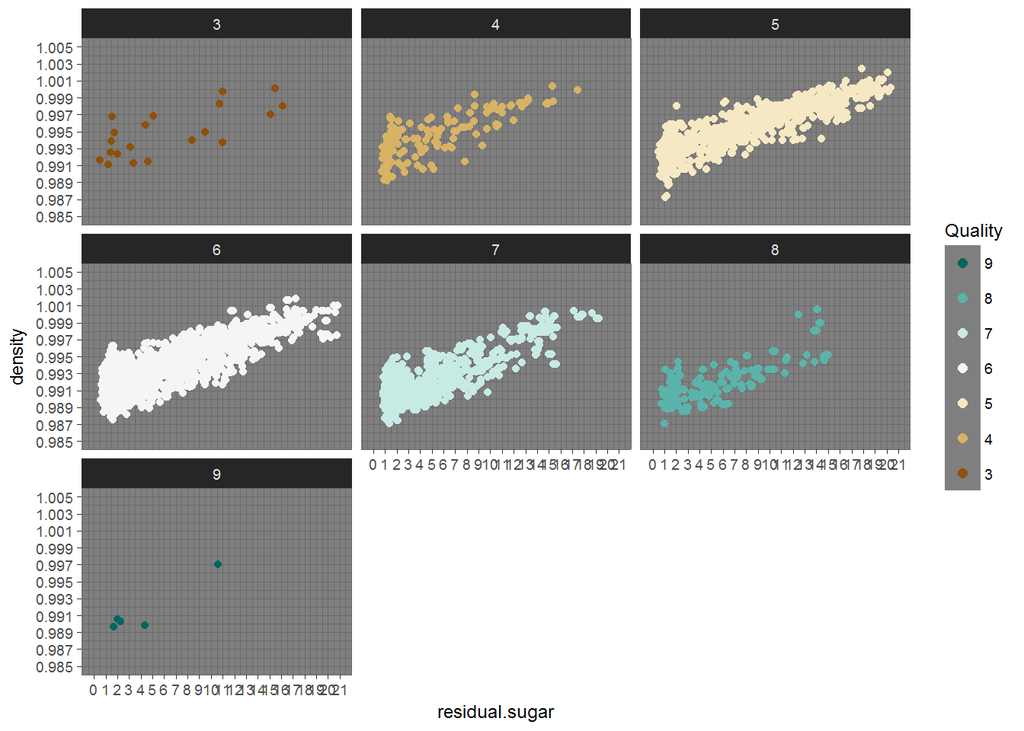

The residual sugar and density relationships have extremely high variation, except at the highest quality level. The majority of wine quality 9, have both low residual sugar and density.

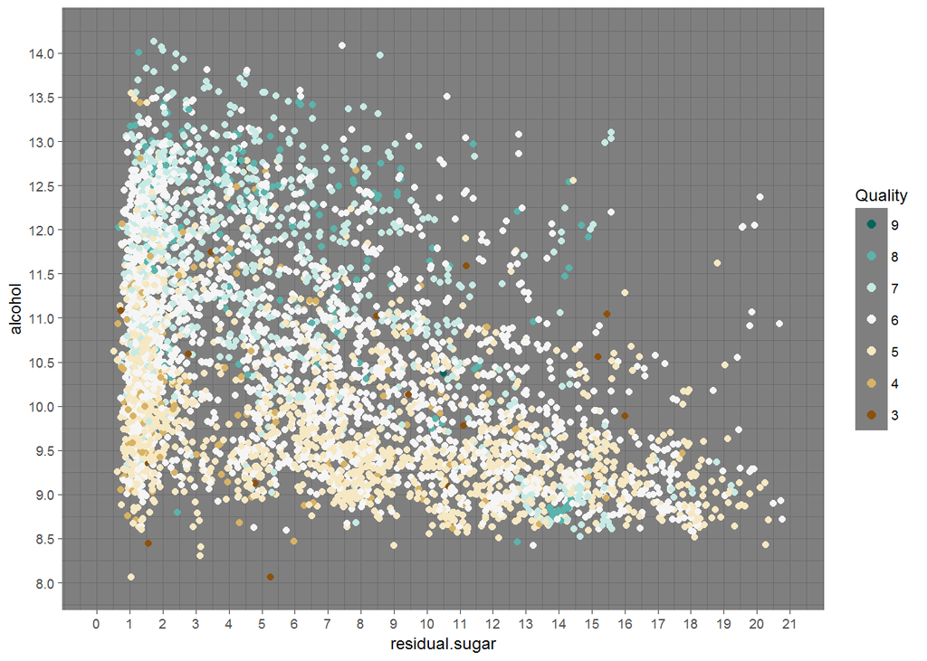

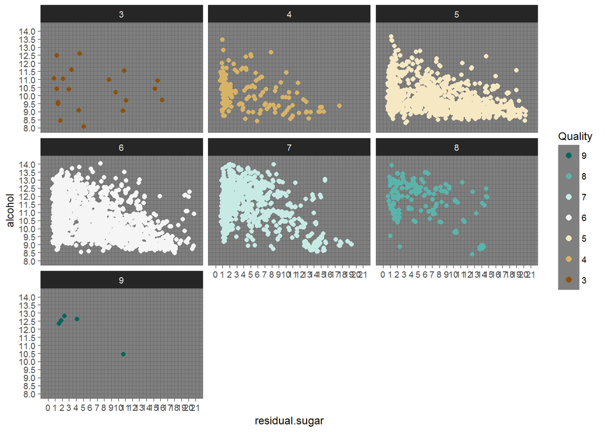

```
##
## Calls:
## m1: lm(formula = quality ~ fixed.acidity, data = wine)
## m2: lm(formula = quality ~ fixed.acidity + volatile.acidity, data = wine)
## m3: lm(formula = quality ~ fixed.acidity + volatile.acidity + citric.acid,
##     data = wine)
## m4: lm(formula = quality ~ fixed.acidity + volatile.acidity + citric.acid +
##     residual.sugar, data = wine)
## m5: lm(formula = quality ~ fixed.acidity + volatile.acidity + citric.acid +
##     residual.sugar + chlorides, data = wine)
## m6: lm(formula = quality ~ fixed.acidity + volatile.acidity + citric.acid +
##     residual.sugar + chlorides + free.sulfur.dioxide, data = wine)
## m7: lm(formula = quality ~ fixed.acidity + volatile.acidity + citric.acid +
##     residual.sugar + chlorides + free.sulfur.dioxide + total.sulfur.dioxide,
##     data = wine)
## m8: lm(formula = quality ~ fixed.acidity + volatile.acidity + citric.acid +
##     residual.sugar + chlorides + free.sulfur.dioxide + total.sulfur.dioxide +
##     density, data = wine)
## m9: lm(formula = quality ~ fixed.acidity + volatile.acidity + citric.acid +
##     residual.sugar + chlorides + free.sulfur.dioxide + total.sulfur.dioxide +
##     density + pH, data = wine)
## m10: lm(formula = quality ~ fixed.acidity + volatile.acidity + citric.acid +
##     residual.sugar + chlorides + free.sulfur.dioxide + total.sulfur.dioxide +
##     density + pH + sulphates, data = wine)
## m11: lm(formula = quality ~ fixed.acidity + volatile.acidity + citric.acid +
##     residual.sugar + chlorides + free.sulfur.dioxide + total.sulfur.dioxide +
##     density + pH + sulphates + alcohol, data = wine)
##
## =========================================================================================================================================================
##                            m1         m2         m3         m4         m5         m6         m7          m8           m9           m10          m11
## ---------------------------------------------------------------------------------------------------------------------------------------------------------
##   (Intercept)            6.696***   7.210***   7.214***   7.232***   7.499***   7.447***   7.519***   237.792***   275.802***   283.857***   150.193***
##                         (0.103)    (0.107)    (0.108)    (0.108)    (0.107)    (0.112)    (0.111)      (8.375)      (8.643)      (8.633)     (18.804)
##   fixed.acidity         -0.119***  -0.124***  -0.122***  -0.117***  -0.121***  -0.118***  -0.100***     0.043**      0.161***     0.166***     0.066**
##                         (0.015)    (0.015)    (0.015)    (0.015)    (0.015)    (0.015)    (0.015)      (0.015)      (0.017)      (0.017)      (0.021)
##   volatile.acidity                 -1.735***  -1.741***  -1.689***  -1.547***  -1.523***  -1.308***    -1.737***    -1.720***    -1.699***    -1.863***
##                                    (0.122)    (0.124)    (0.124)    (0.122)    (0.123)    (0.123)      (0.116)      (0.113)      (0.113)      (0.114)
##   citric.acid                                 -0.037      0.011      0.187      0.175      0.216*       0.108        0.148        0.094        0.022
##                                               (0.108)    (0.108)    (0.106)    (0.107)    (0.106)      (0.098)      (0.096)      (0.096)      (0.096)
##   residual.sugar                                         -0.013***  -0.011***  -0.012***  -0.005*       0.097***     0.124***     0.128***     0.081***
```

[output cut: 12 more lines]

```
##                                                                                                                                  (0.098)      (0.100)
##   alcohol                                                                                                                                      0.193***
##                                                                                                                                               (0.024)
## ---------------------------------------------------------------------------------------------------------------------------------------------------------
##   R-squared                 0.013      0.052      0.052      0.057      0.093      0.094      0.113       0.232        0.262        0.272        0.282
##   adj. R-squared            0.013      0.051      0.051      0.057      0.093      0.093      0.112       0.231        0.260        0.271        0.280
##   sigma                     0.880      0.863      0.863      0.860      0.844      0.844      0.835       0.777        0.762        0.756        0.751
##   F                        64.080    133.891     89.284     74.586    100.908     84.563     89.011     184.417      192.626      183.046      174.344
##   p                         0.000      0.000      0.000      0.000      0.000      0.000      0.000       0.000        0.000        0.000        0.000
##   Log-likelihood        -6322.771  -6224.180  -6224.120  -6209.668  -6114.231  -6112.896  -6060.905   -5708.762    -5611.200    -5575.514    -5543.740
##   Deviance               3791.367   3641.766   3641.678   3620.250   3481.884   3479.986   3406.887    2950.599     2835.366     2794.349     2758.329
##   AIC                   12651.543  12456.360  12458.240  12431.336  12242.462  12241.792  12139.811   11437.524    11244.401    11175.028    11113.480
##   BIC                   12671.032  12482.346  12490.723  12470.315  12287.939  12293.764  12198.280   11502.490    11315.863    11252.987    11197.936
##   N                      4898       4898       4898       4898       4898       4898       4898        4898         4898         4898         4898
## =========================================================================================================================================================
```

The linear model created has extremely low R-squared values. This could be due to the diversity of the dataset given in the original wine dataset. The majority of the data given has a wine quality value of 5, 6, 7. Shown in the quality bar graph in the Univariate section. Having a more diverse dataset would lead to a better modeling of the data.

# Multivariate Analysis

### Talk about some of the relationships you observed in this part of the investigation. Were there features that strengthened each other in terms of looking at your feature of interest?

The density vs alcohol graph showing the quality of the wines was insightful. There seemed to be an overall trend, as you can see the shifting of plot points as the quality of wine increases.

The density vs residual sugar graph showing the quality of the wines, highlighted the variation of wines with low wine quality, while the high quality wines seemed to converge around a similar density/residual sugar ratio.

The alcohol vs residual sugar graph was a mix between the trends shown in the first two graphs in reference to the wine quality values. As the wine quality increased, the movement trend of the alcohol/residual sugar ratio was shown, as well as a decrease in variation of the feature values as the wine quality increased.

### Were there any interesting or surprising interactions between features?

The general decrease in variation of the observed features as the wine quality increased was interesting. From this dataset it showed that as the wine quality increases the wine features converge to a given range of feature values, for the observed features.

### OPTIONAL: Did you create any models with your dataset? Discuss the strengths and limitations of your model.

Yes, a linear model was created for this dataset. The reported R-squared values are extremely low. This is most likely due to the lack of variation within the dataset for the wine quality values. This dataset does not fair well for predictive linear models, when the output feature (wine quality) is so concentrated in <30% of the possible wine quality values.

# Final Plots and Summary

### Plot One

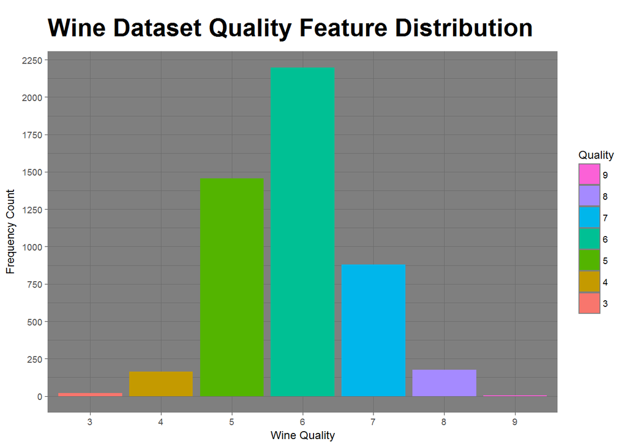

### Description One

The distribution of wine qualities appears to be normal, centered around 6 but, due to the lack of variation in the wine quality feature, it was difficult to determine what contributes to a high quality or low quality wine, due to the majority of wines in this dataset having an average quality.

### Plot Two

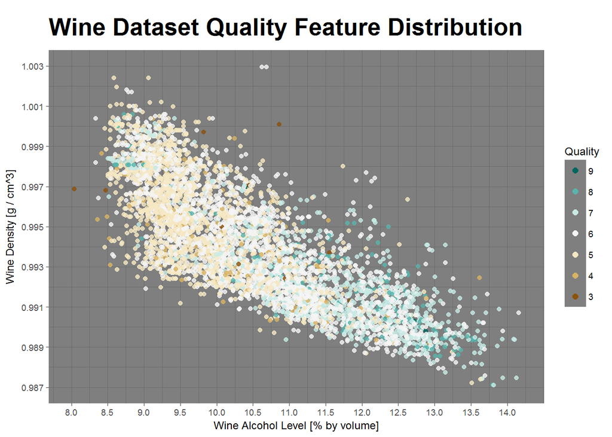

### Description Two

The average wine quality is over represented within this wine dataset but with the above graph it is clear that the majority of high quality wines tend to have high alcohol levels and low density levels.

### Plot Three

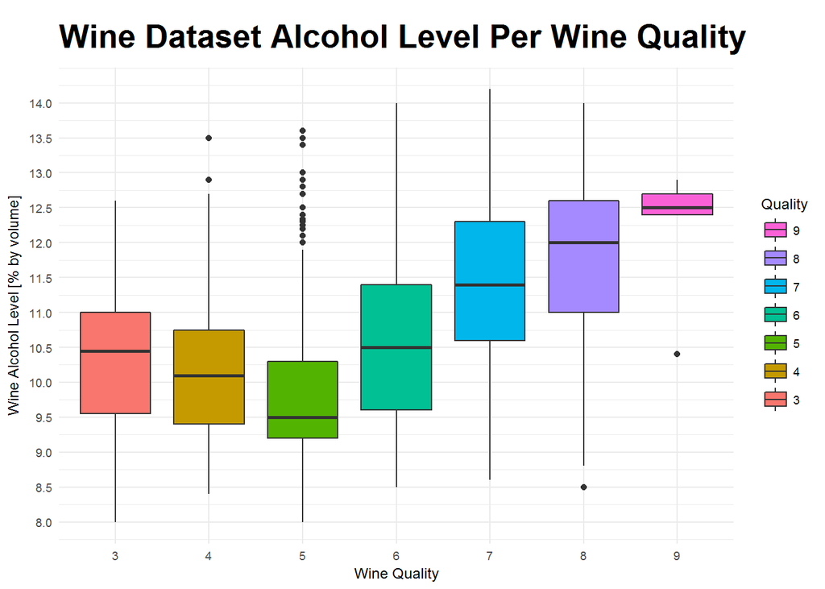

### Description Three

The alcohol level of a wine by volume tends to be positively correlated and increase with the wine quality level. Generally, in the dataset given, the higher the median alcohol value, the higher the quality of wine.

# Reflection

The white wine data set contains information on almost 5,000 wines, with 12 different features, and was created in 2009. I started by observing the distributions of each feature within the dataset. From there I took note of any trends, abnormalities, and possible insights into the meanings behind the features. I then started cross plotting and correlating the different features with quality, and some of the features with other input features given in the dataset. Finally, I explored the additive effects of features on the overall wine quality feature and created a linear model to better understand the dataset.

There was a clear trend with median alcohol content and wine quality. There were also clear trends with a combination of residual sugars, alcohol, density, and wine quality. Some of these variables could be dependent upon each other, more domain knowledge is needed for further insight into the data exploration. The relationships between the afore mentioned features became more clear, when scatter plots were created, and separated by wine quality. The plot points migrated, converged, and created a clear underlying relationship to the wine quality.

Unfortunately, the dataset given is heavily concentrated on average wine qualities. The lowest, and highest wine quality levels were sparse within this dataset. Giving way to a poor predictive linear model, with a low R-squared value, due to the lack of variation in the wine quality (output feature). This data could also be non-linear, feature incomplete, and otherwise not verbose enough to gain a more definitive model. Other machine learning models were not attempted, and a linear model might not be the best approach to modeling this dataset. For future work, a wider range of features for the wine, such as, price, age, location of production, and other features would greatly enrich the dataset. In the end, a median high alcohol percentage wine, gave way to a higher quality wine, other features could and do impact the wine quality value but, this feature trended strongly given the final box plot shown within this exploration.

# References

Citation Request: This dataset is public available for research. The details are described in [Cortez et al., 2009]. Please include this citation if you plan to use this database:

P. Cortez, A. Cerdeira, F. Almeida, T. Matos and J. Reis. Modeling wine preferences by data mining from physicochemical properties. In Decision Support Systems, Elsevier, 47(4):547-553. ISSN: 0167-9236.

Available at: [@Elsevier] http://dx.doi.org/10.1016/j.dss.2009.05.016 [Pre-press (pdf)] http://www3.dsi.uminho.pt/pcortez/winequality09.pdf [bib] http://www3.dsi.uminho.pt/pcortez/dss09.bib